# Data Science for Public Policy (assignment04)

Author

Sejin Kim (Net ID: sk2723)

# Education, Gender, and Economic Outcomes in the United States

## 1. Educational Attainment Across U.S. States

The first visualization provides an overview of educational attainment among adults age 25 and older across the 50 U.S. states in 2024. The share with a bachelor’s degree or higher varies considerably across states, showing clear geographic differences. These differences provide a starting point for examining whether higher educational attainment is associated with higher household income. From a policy perspective, the variation may help identify states where expanding access to higher education could be particularly relevant.  
(Data source: [U.S. Census Bureau, 2024 ACS 1-Year Estimates, Table B15003](https://data.census.gov/table?q=B15003&g=010XX00US$0400000&y=2024))

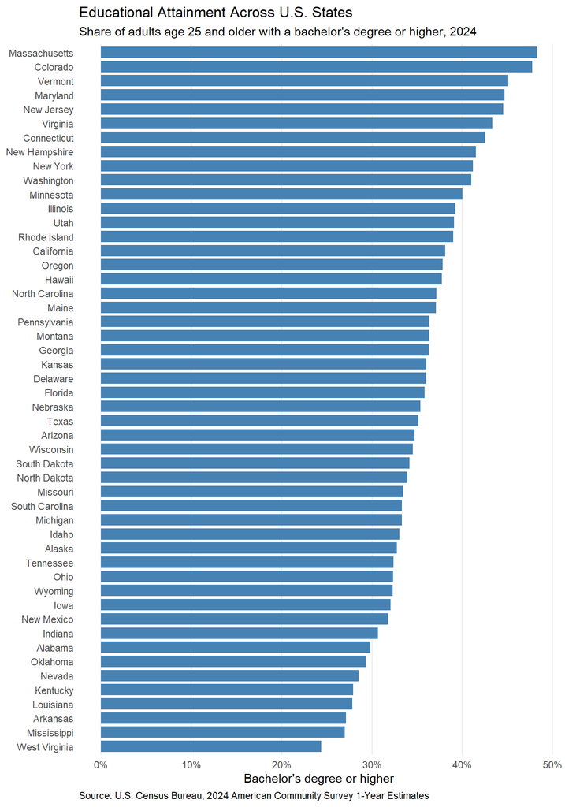

```r
library(tidyverse)

education <- read_csv("data/B15003.csv")

education <- education |>
  select(`Label (Grouping)`, ends_with("Estimate")) |>
  rename(
    label = `Label (Grouping)`
  ) |>
  rename_with(
    ~ str_remove(.x, "!!Estimate$"),
    ends_with("!!Estimate")
  ) |>
  pivot_longer(
    cols = -label,
    names_to = "state",
    values_to = "population"
  ) |>
  mutate(label = str_trim(label))


education_bachelor <- education |>
  filter(
    label %in% c(
      "Total:",
      "Bachelor's degree",
      "Master's degree",
      "Professional school degree",
      "Doctorate degree"
    )
  ) |>
  group_by(state) |>
  summarize(
    total = population[label == "Total:"],
    bachelor_plus = sum(population[label != "Total:"]),
    bachelor_pct = bachelor_plus / total * 100
  ) |>
  filter(!state %in% c("Puerto Rico", "District of Columbia"))

education_bachelor |>
  ggplot(aes(
    x = bachelor_pct,
    y = reorder(state, bachelor_pct)
  )) +
  geom_col(
    fill = "steelblue",
    width = 0.8
  ) +
  scale_x_continuous(
    labels = scales::label_percent(scale = 1)
  ) +
  labs(
    title = "Educational Attainment Across U.S. States",
    subtitle = "Share of adults age 25 and older with a bachelor's degree or higher, 2024",
    x = "Bachelor's degree or higher",
    y = NULL,
    caption = "Source: U.S. Census Bureau, 2024 American Community Survey 1-Year Estimates"
  ) +
  theme_minimal() +
  theme(
    panel.grid.major.y = element_blank(),
    panel.grid.minor = element_blank(),
    plot.caption = element_text(hjust = 0)
  )
```

## 2. Educational Attainment and Household Income

The first visualization showed substantial differences in educational attainment across states. This visualization examines whether those differences are associated with household income and shows a positive relationship: states with higher shares of adults holding a bachelor’s degree or higher generally have higher median household incomes. Although this relationship does not establish that higher educational attainment causes higher income, it suggests that education and economic outcomes are closely associated across states. From a policy perspective, the pattern highlights the importance of considering education alongside other economic and regional factors when examining differences in household income across states.  
(Data source: [U.S. Census Bureau, 2024 ACS 1-Year Estimates, Table B19013](https://data.census.gov/table?q=B19013&g=010XX00US$0400000&y=2024)

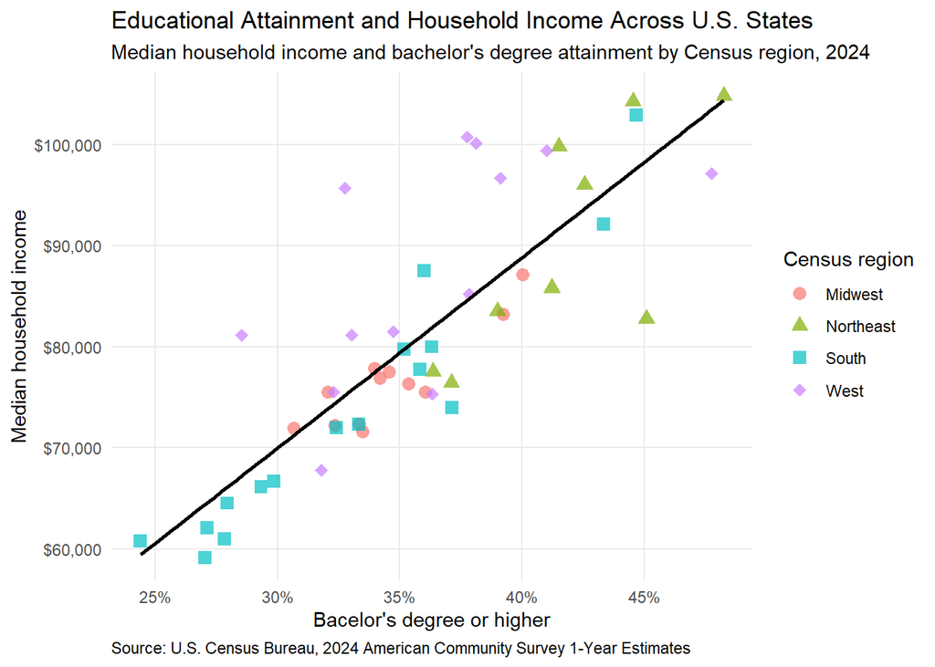

```r
income <- read_csv("data/B19013.csv")

income <- income |>
  select(ends_with("Estimate")) |>
  rename_with(
    ~ str_remove(.x, "!!Estimate$"),
    ends_with("!!Estimate")
  ) |>
  pivot_longer(
    cols = everything(),
    names_to = "state",
    values_to = "median_income"
  ) |>
  filter(!state %in% c("District of Columbia", "Puerto Rico"))

education_income <- education_bachelor |>
  left_join(income, by = "state") |>
  mutate(region = case_when(
    state %in% c(
      "Connecticut", "Maine", "Massachusetts", "New Hampshire", "Rhode Island", "Vermont", "New Jersey", "New York", "Pennsylvania") ~ "Northeast",
    state %in% c(
      "Indiana", "Illinois", "Michigan", "Ohio", "Wisconsin", "Iowa", "Kansas", "Minnesota", "Missouri", "Nebraska", "North Dakota", "South Dakota") ~ "Midwest",
    state %in% c(
      "Delaware", "Florida", "Georgia", "Maryland", "North Carolina", "South Carolina", "Virginia", "West Virginia", "Alabama", "Kentucky", "Mississippi", "Tennessee", "Arkansas", "Louisiana", "Oklahoma", "Texas") ~ "South",
    state %in% c(
      "Arizona", "Colorado", "Idaho", "Montana", "Nevada", "New Mexico", "Utah", "Wyoming", "Alaska", "California", "Hawaii", "Oregon", "Washington"
    ) ~ "West"
  ))

education_income |>
  ggplot(aes(
    x = bachelor_pct,
    y = median_income
  )) +
  geom_point(
    aes(color = region,
        shape = region),
    size = 3,
    alpha = 0.7,
  ) +
  geom_smooth(
    method = "lm",
    se = FALSE,
    color = "black"
  ) +
  scale_shape_manual(
    values = c(
      "Midwest" = 16,
      "Northeast" = 17,
      "South" = 15,
      "West" = 18
    )
  ) +
  scale_x_continuous(
    labels = scales::label_percent(scale = 1)
  ) +
  scale_y_continuous(
    labels = scales::label_dollar()
  ) +
  labs(
    title = "Educational Attainment and Household Income Across U.S. States",
    subtitle = "Median household income and bachelor's degree attainment by Census region, 2024",
    x = "Bacelor's degree or higher",
    y = "Median household income",
    color = "Census region",
    shape = "Census region",
    caption = "Source: U.S. Census Bureau, 2024 American Community Survey 1-Year Estimates"
  ) +
  theme_minimal() +
  theme(
    panel.grid.minor = element_blank(),
    plot.caption = element_text(hjust = 0)
  )
```

## 3. Gender Differences in Educational Attainment

The first two visualizations examined educational attainment across states and its relationship with household income. This visualization adds a gender dimension by comparing bachelor’s degree attainment between men and women across states. Women generally have higher rates of bachelor’s degree attainment than men across U.S. states, although the size of the gap varies by state. This pattern raises an important question: does women’s higher educational attainment translate into similar or higher economic outcomes?  
(Data source: [U.S. Census Bureau, 2024 ACS 1-Year Estimates, Table B15002](https://data.census.gov/table?q=B15002&g=010XX00US$0400000&y=2024)

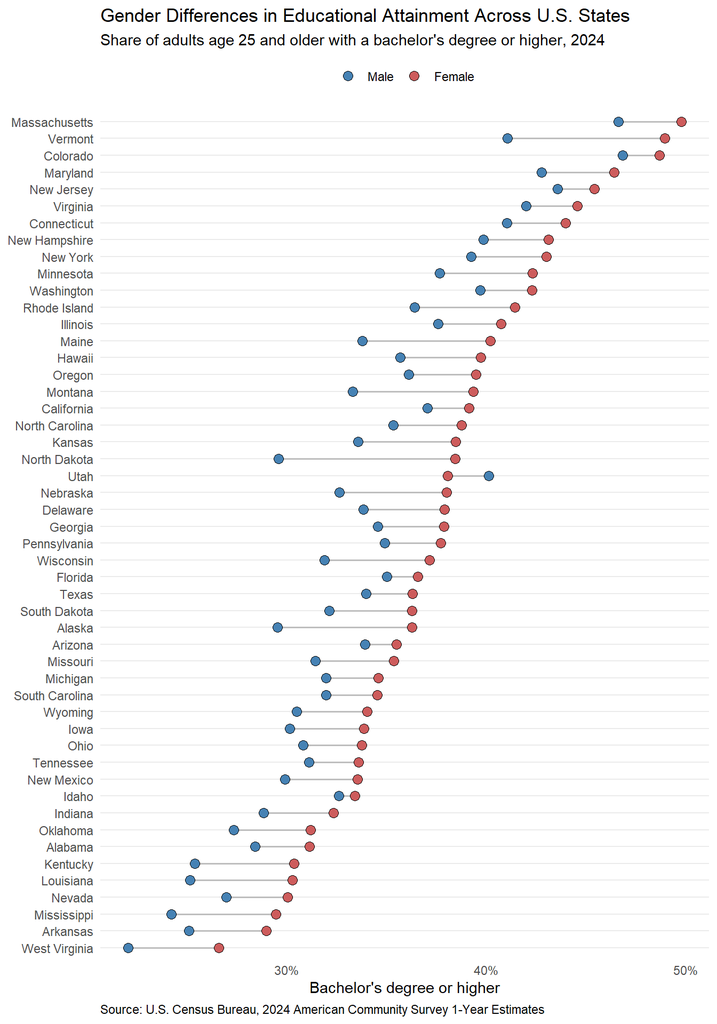

```r
gender <- read_csv("data/B15002.csv")

gender <- gender |>
  mutate(
    label = str_trim(`Label (Grouping)`),
    sex = case_when(
      label == "Male:" ~ "Male",
      label == "Female:" ~ "Female"
    )
  ) |>
  fill(sex) |>
  select(-`Label (Grouping)`)

gender <- gender |>
  select(label, sex, ends_with("Estimate")) |>
  rename_with(
    ~ str_remove(.x, "!!Estimate$"),
    ends_with("!!Estimate")
  ) |>
  pivot_longer(
    cols = -c(label, sex),
    names_to = "state",
    values_to = "population"
  )

gender_bachelor <- gender |>
  filter(
    label %in% c(
      "Male:",
      "Female:",
      "Bachelor's degree",
      "Master's degree",
      "Professional school degree",
      "Doctorate degree"
    )) |>
  group_by(state, sex) |>
  summarize(
    total = population[label %in% c("Male:", "Female:")],
    bachelor_plus = sum(
      population[label %in% c(
        "Bachelor's degree",
        "Master's degree",
        "Professional school degree",
        "Doctorate degree"
      )]
    ),
    bachelor_pct = bachelor_plus / total * 100) |>
  ungroup() |>
  filter(!state %in% c("District of Columbia", "Puerto Rico"))

gender_plot <- gender_bachelor |>
  select(state, sex, bachelor_pct) |>
  pivot_wider(
    names_from = sex,
    values_from = bachelor_pct
  ) |>
  mutate(
    state = reorder(state, Female)
  )

gender_bachelor <- gender_bachelor |>
  mutate(state = factor(state, levels = levels(gender_plot$state)))

gender_plot |>
  ggplot(aes(y = state)) +
  geom_segment(
    aes(
      x = Male,
      xend = Female,
      yend = state
    ),
    linewidth = 0.7,
    color = "grey"
  ) +
  geom_point(
    data = gender_bachelor,
    aes(
      x = bachelor_pct,
      fill = sex
      ),
    shape = 21,
    size = 3
  ) +
  scale_fill_manual(
    values = c(
      "Male" = "steelblue",
      "Female" = "indianred"),
      breaks = c("Male", "Female")
    ) +
  scale_x_continuous(
    labels = scales::label_percent(scale = 1)
  ) +
  labs(
    title = "Gender Differences in Educational Attainment Across U.S. States",
    subtitle = "Share of adults age 25 and older with a bachelor's degree or higher, 2024",
    x = "Bachelor's degree or higher",
    y = NULL,
    fill = "Sex",
    caption = "Source: U.S. Census Bureau, 2024 American Community Survey 1-Year Estimates"
  ) +
  theme_minimal() +
  theme(
    legend.position = "top",
    legend.title = element_blank(),
    panel.grid.major.x = element_blank(),
    panel.grid.minor = element_blank(),
    plot.caption = element_text(hjust = 0)
  )
```

## 4. Earnings Rise with Education, but the Gender Gap Persists

The previous visualization showed that women generally have higher rates of bachelor’s degree attainment than men across states. However, median earnings are higher for men at every level of educational attainment, even as earnings increase with education for both groups. The earnings gap also becomes larger at the bachelor’s and graduate levels. This contrast suggests that differences in educational attainment alone do not fully explain the gender gap in earnings, highlighting the need to consider other labor market factors.  
(Data source: [U.S. Census Bureau, 2024 ACS 1-Year Estimates, Table B20004](https://data.census.gov/table?q=B20004&g=010XX00US&y=2024)

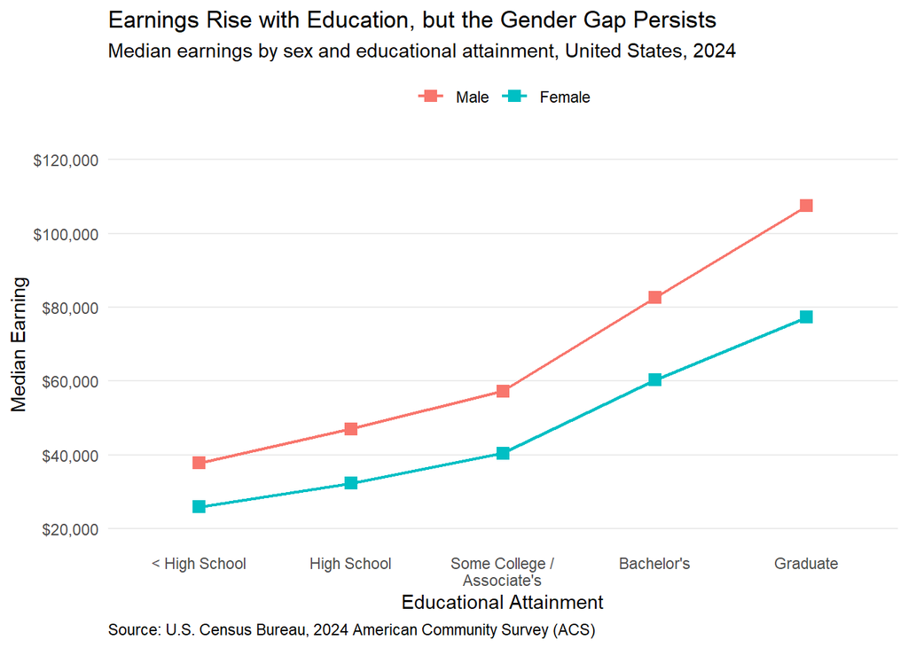

```r
earning <- read_csv("data/B20004.csv")

earning <- earning |>
  rename(
    label = `Label (Grouping)`,
    median_earning = `United States!!Estimate`,
    moe = `United States!!Margin of Error`
  ) |>
  mutate(
    label = str_trim(label),
    sex = case_when(
      label == "Male:" ~ "Male",
      label == "Female:" ~ "Female"
    )) |>
  fill(sex) |>
  filter(!is.na(sex)) |>
  filter(!label %in% c("Male:", "Female:"))


earning <- earning |>
  mutate(
    moe = parse_number(moe),
    sex = factor(sex, levels = c("Male", "Female")),
    label = factor(
      label,
      levels = c(
        "Less than high school graduate",
        "High school graduate (includes equivalency)",
        "Some college or associate's degree",
        "Bachelor's degree",
        "Graduate or professional degree"
      ),
      labels = c(
        "< High School",
        "High School",
        "Some College /\nAssociate's",
        "Bachelor's",
        "Graduate"
      )))

ggplot(
  earning,
  aes(
    x = label,
    y = median_earning,
    color = sex,
    group = sex
  )
) +
  geom_line(
    linewidth = 0.8
  ) +
  geom_point(
    size = 3,
    shape = 15
  ) +
  scale_y_continuous(
    labels = scales::label_dollar(),
    breaks = seq(20000, 120000, 20000),
    limits = c(20000, 120000)
  ) +
  labs(
    title = "Earnings Rise with Education, but the Gender Gap Persists",
    subtitle = "Median earnings by sex and educational attainment, United States, 2024",
    x = "Educational Attainment",
    y = "Median Earning",
    color = NULL,
    caption = "Source: U.S. Census Bureau, 2024 American Community Survey (ACS)"
  ) +
  theme_minimal() +
  theme(
    legend.position = "top",
    panel.grid.major.x = element_blank(),
    panel.grid.minor = element_blank(),
    plot.caption = element_text(hjust = 0))
```

## Visualization Requirements Checklist

| Requirement Category | Specific Element / Code Used | Graph # (1, 2, 3, or 4) |
| --- | --- | --- |
| **Geom 1** | `geom_col()` | 1 |
| **Geom 2** | `geom_point()` | 2 |
| **Geom 3** | `geom_smooth()` | 2 |
| **Geom 4** | `geom_segment()` | 3 |
| **Geom 5** | `geom_line()` | 4 |
| **Aesthetic 1** *(inside `aes()`)* | `x = bachelor_pct` | 1 |
| **Aesthetic 2** *(inside `aes()`)* | `color = region` | 2 |
| **Aesthetic 3** *(inside `aes()`)* | `shape = region` | 2 |
| **Aesthetic 4** *(inside `aes()`)* | `xend = female` | 3 |
| **Aesthetic 5** *(inside `aes()`)* | `fill = sex` | 3 |
| **Aesthetic 6** *(inside `aes()`)* | `group = sex` | 4 |
| **Non-Aesthetic 1** *(outside `aes()`)* | `fill = "steelblue"` | 1 |
| **Non-Aesthetic 2** *(outside `aes()`)* | `width = 0.8` | 1 |
| **Non-Aesthetic 3** *(outside `aes()`)* | `size = 3` | 2 |
| **Non-Aesthetic 4** *(outside `aes()`)* | `alpha = 0.7` | 2 |
| **Non-Aesthetic 5** *(outside `aes()`)* | `color = "black"` | 2 |
| **Non-Aesthetic 6** *(outside `aes()`)* | `linewidth = 0.7` | 3 |
| **Custom Scale 1** | `scale_shape_manual()` | 2 |
| **Custom Scale 2** | `scale_y_continuous()` | 2 |